# Project: Investigate a Dataset TMDb_Movies Dataset

- Introduction
- Data Wrangling
- Exploratory Data Analysis
- Conclusions

## Introduction

**The Movie Database**: This data set contains information about 10 thaosnd movies collected from The Movie Database (TMDb), including user ratings and revenue,cast,release year.

**Question that can analyised from this data set**

- describe the budget, revenue and runtime
- Calculating the profit of the each movie
- correlation between variable

```python
import pandas as pd
import numpy as np
import matplotlib.pyplot as plt
% matplotlib inline
```

## Data Wrangling

### General Properties

```python
#Read TMDb movie csv file
df = pd.read_csv('tmdb-movies.csv')
df.head()
```

|  | id | imdb_id | popularity | budget | revenue | original_title | cast | homepage | director | tagline | ... | overview | runtime | genres | production_companies | release_date | vote_count | vote_average | release_year | budget_adj | revenue_adj |
| --- | --- | --- | --- | --- | --- | --- | --- | --- | --- | --- | --- | --- | --- | --- | --- | --- | --- | --- | --- | --- | --- |
| 0 | 135397 | tt0369610 | 32.985763 | 150000000 | 1513528810 | Jurassic World | Chris Pratt\|Bryce Dallas Howard\|Irrfan Khan\|Vi... | http://www.jurassicworld.com/ | Colin Trevorrow | The park is open. | ... | Twenty-two years after the events of Jurassic ... | 124 | Action\|Adventure\|Science Fiction\|Thriller | Universal Studios\|Amblin Entertainment\|Legenda... | 6/9/15 | 5562 | 6.5 | 2015 | 1.379999e+08 | 1.392446e+09 |
| 1 | 76341 | tt1392190 | 28.419936 | 150000000 | 378436354 | Mad Max: Fury Road | Tom Hardy\|Charlize Theron\|Hugh Keays-Byrne\|Nic... | http://www.madmaxmovie.com/ | George Miller | What a Lovely Day. | ... | An apocalyptic story set in the furthest reach... | 120 | Action\|Adventure\|Science Fiction\|Thriller | Village Roadshow Pictures\|Kennedy Miller Produ... | 5/13/15 | 6185 | 7.1 | 2015 | 1.379999e+08 | 3.481613e+08 |
| 2 | 262500 | tt2908446 | 13.112507 | 110000000 | 295238201 | Insurgent | Shailene Woodley\|Theo James\|Kate Winslet\|Ansel... | http://www.thedivergentseries.movie/#insurgent | Robert Schwentke | One Choice Can Destroy You | ... | Beatrice Prior must confront her inner demons ... | 119 | Adventure\|Science Fiction\|Thriller | Summit Entertainment\|Mandeville Films\|Red Wago... | 3/18/15 | 2480 | 6.3 | 2015 | 1.012000e+08 | 2.716190e+08 |
| 3 | 140607 | tt2488496 | 11.173104 | 200000000 | 2068178225 | Star Wars: The Force Awakens | Harrison Ford\|Mark Hamill\|Carrie Fisher\|Adam D... | http://www.starwars.com/films/star-wars-episod... | J.J. Abrams | Every generation has a story. | ... | Thirty years after defeating the Galactic Empi... | 136 | Action\|Adventure\|Science Fiction\|Fantasy | Lucasfilm\|Truenorth Productions\|Bad Robot | 12/15/15 | 5292 | 7.5 | 2015 | 1.839999e+08 | 1.902723e+09 |
| 4 | 168259 | tt2820852 | 9.335014 | 190000000 | 1506249360 | Furious 7 | Vin Diesel\|Paul Walker\|Jason Statham\|Michelle ... | http://www.furious7.com/ | James Wan | Vengeance Hits Home | ... | Deckard Shaw seeks revenge against Dominic Tor... | 137 | Action\|Crime\|Thriller | Universal Pictures\|Original Film\|Media Rights ... | 4/1/15 | 2947 | 7.3 | 2015 | 1.747999e+08 | 1.385749e+09 |

5 rows × 21 columns

### Data Cleaning (Removing the unused information from the dataset)

- Removing the duplicaty in the rows.
- remove unused column such as id, imdb_id, vote_count, production_company etc.
- Removing the missing revenue in the database.
- Checking the current format of columns in the dataset and changing.

**Let's get intuition of our data by checking its types,null values,duplicates and Dropping Columns:**

**Dropping Columns:**

```python
#remove unused column such as id, imdb_id, vote_count, production_company etc.

del_col=[ 'id', 'imdb_id', 'popularity', 'budget_adj', 'revenue_adj', 'homepage', 'keywords', 'overview', 'production_companies', 'vote_count', 'vote_average']

df= df.drop(del_col,1)
df.head()
```

|  | budget | revenue | original_title | cast | director | tagline | runtime | genres | release_date | release_year |
| --- | --- | --- | --- | --- | --- | --- | --- | --- | --- | --- |
| 0 | 150000000 | 1513528810 | Jurassic World | Chris Pratt\|Bryce Dallas Howard\|Irrfan Khan\|Vi... | Colin Trevorrow | The park is open. | 124 | Action\|Adventure\|Science Fiction\|Thriller | 6/9/15 | 2015 |
| 1 | 150000000 | 378436354 | Mad Max: Fury Road | Tom Hardy\|Charlize Theron\|Hugh Keays-Byrne\|Nic... | George Miller | What a Lovely Day. | 120 | Action\|Adventure\|Science Fiction\|Thriller | 5/13/15 | 2015 |
| 2 | 110000000 | 295238201 | Insurgent | Shailene Woodley\|Theo James\|Kate Winslet\|Ansel... | Robert Schwentke | One Choice Can Destroy You | 119 | Adventure\|Science Fiction\|Thriller | 3/18/15 | 2015 |
| 3 | 200000000 | 2068178225 | Star Wars: The Force Awakens | Harrison Ford\|Mark Hamill\|Carrie Fisher\|Adam D... | J.J. Abrams | Every generation has a story. | 136 | Action\|Adventure\|Science Fiction\|Fantasy | 12/15/15 | 2015 |
| 4 | 190000000 | 1506249360 | Furious 7 | Vin Diesel\|Paul Walker\|Jason Statham\|Michelle ... | James Wan | Vengeance Hits Home | 137 | Action\|Crime\|Thriller | 4/1/15 | 2015 |

**Removing the duplicacy in the rows**

```python
#Removing the duplicacy in the rows

rows, col = df.shape
print('total entries of movies {} and number of columns {} '.format(rows-1, col))

#now removing
df.drop_duplicates(keep ='first', inplace=True)
rows, col = df.shape

print('total entries of movies {} and number of columns {} '.format(rows-1, col))
```

```
total entries of movies 10865 and number of columns 10
total entries of movies 10864 and number of columns 10
```

**Removing the missing revenue in the database.

```python
#Removing the missing revenue in the database.

temp_list=['budget', 'revenue']

#then replace it to NAN
df[temp_list] = df[temp_list].replace(0, np.NAN)

df.dropna(subset = temp_list, inplace = True)

rows, col = df.shape
print(' now we have only {} no.of movies.'.format(rows-1))
```

```
 now we have only 3853 no.of movies.
```

**Checking the current types of columns in the dataset and changing

```python
#Checking the current format of columns in the dataset and changing
df.dtypes

#then change the budget and revenue to integr values
change_type=['budget', 'revenue']

df[change_type]=df[change_type].applymap(np.int64)

#Show the types after changing
df.dtypes
```

```
budget             int64
revenue            int64
original_title    object
cast              object
director          object
tagline           object
runtime            int64
genres            object
release_date      object
release_year       int64
dtype: object
```

## Exploratory Data Analysis

### Research Question 1 (describe the budget, revenue and runtime)

```python
df['budget'].describe()
```

```
count    3.854000e+03
mean     3.720370e+07
std      4.220822e+07
min      1.000000e+00
25%      1.000000e+07
50%      2.400000e+07
75%      5.000000e+07
max      4.250000e+08
Name: budget, dtype: float64
```

```python
df['revenue'].describe()
```

```
count    3.854000e+03
mean     1.076866e+08
std      1.765393e+08
min      2.000000e+00
25%      1.360003e+07
50%      4.480000e+07
75%      1.242125e+08
max      2.781506e+09
Name: revenue, dtype: float64
```

```python
df['runtime'].describe()
```

```
count    3854.000000
mean      109.220291
std        19.922820
min        15.000000
25%        95.000000
50%       106.000000
75%       119.000000
max       338.000000
Name: runtime, dtype: float64
```

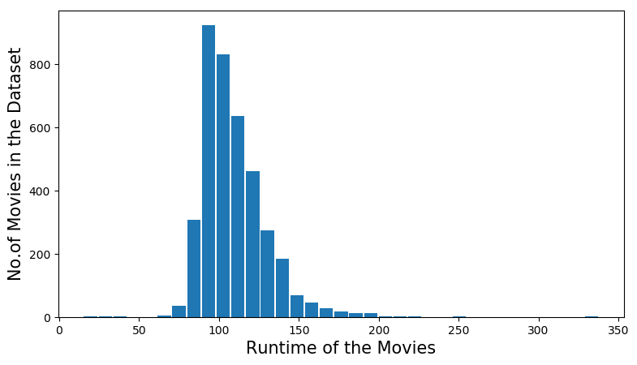

```python
#plotting a histogram of runtime of movies

plt.figure(figsize=(9,5), dpi = 100)

plt.xlabel('Runtime of the Movies', fontsize = 15)

plt.ylabel('No.of Movies in the Dataset', fontsize=15)


plt.hist(df['runtime'], rwidth = 0.9, bins =35)

plt.show()
```

**Right-Skewed Histogram**

- In a histogram, outliers appear as an isolated bar.
- Most of the movies are timed between 80 to 140 minutes.
- at 90 runtime is the most values tend to occur.
- Mode < median < mean

### Research Question 2 (Calculating the profit of the each movie)

```python
df.insert(4,'profit',df['revenue']-df['budget'])

df.head(4)
```

|  | budget | revenue | original_title | cast | profit | director | tagline | runtime | genres | release_date | release_year |
| --- | --- | --- | --- | --- | --- | --- | --- | --- | --- | --- | --- |
| 0 | 150000000 | 1513528810 | Jurassic World | Chris Pratt\|Bryce Dallas Howard\|Irrfan Khan\|Vi... | 1363528810 | Colin Trevorrow | The park is open. | 124 | Action\|Adventure\|Science Fiction\|Thriller | 6/9/15 | 2015 |
| 1 | 150000000 | 378436354 | Mad Max: Fury Road | Tom Hardy\|Charlize Theron\|Hugh Keays-Byrne\|Nic... | 228436354 | George Miller | What a Lovely Day. | 120 | Action\|Adventure\|Science Fiction\|Thriller | 5/13/15 | 2015 |
| 2 | 110000000 | 295238201 | Insurgent | Shailene Woodley\|Theo James\|Kate Winslet\|Ansel... | 185238201 | Robert Schwentke | One Choice Can Destroy You | 119 | Adventure\|Science Fiction\|Thriller | 3/18/15 | 2015 |
| 3 | 200000000 | 2068178225 | Star Wars: The Force Awakens | Harrison Ford\|Mark Hamill\|Carrie Fisher\|Adam D... | 1868178225 | J.J. Abrams | Every generation has a story. | 136 | Action\|Adventure\|Science Fiction\|Fantasy | 12/15/15 | 2015 |

# Research Question 3 ( correlation between variable )

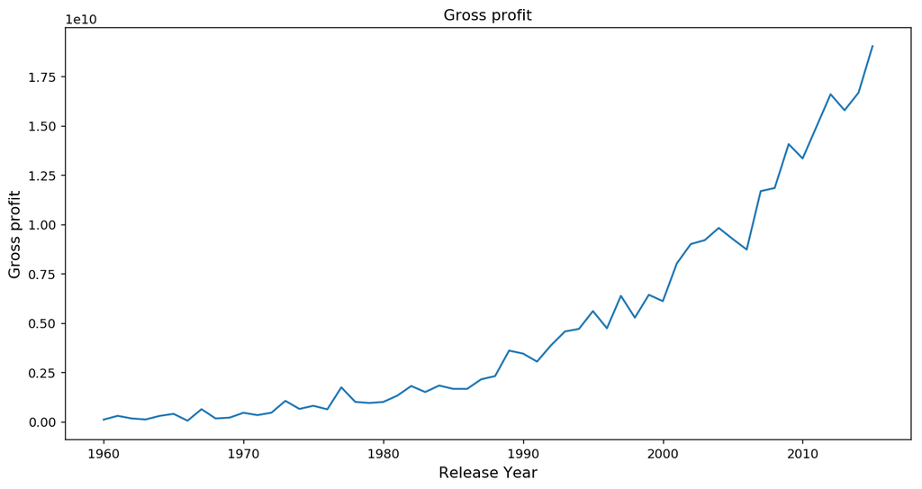

```python
#profit for every year
profit_year = df.groupby('release_year')['profit'].sum()


plt.figure(figsize=(12,6), dpi = 130)

plt.xlabel('Release Year', fontsize = 12)

plt.ylabel('Gross profit', fontsize = 12)

plt.title('Gross profit')

#plotting the graph
plt.plot(profit_year)

#displaying the line plot
plt.show()
```

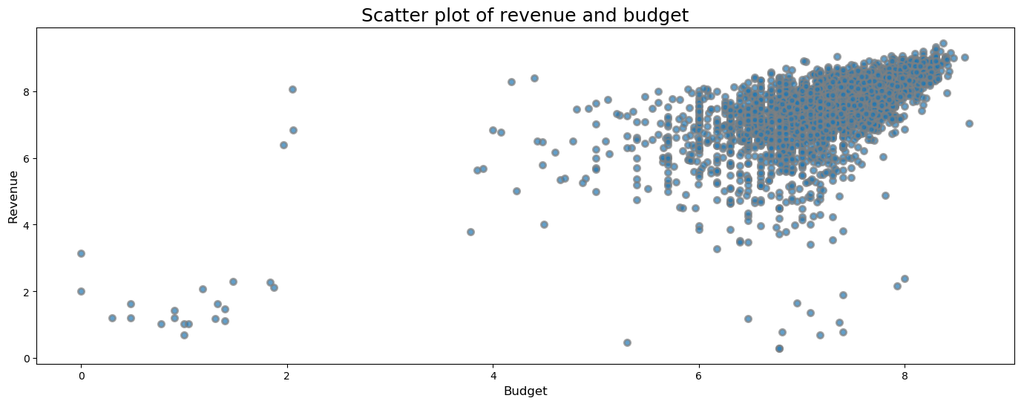

```python
plt.figure(figsize = (17,6),dpi = 100);
plt.scatter(x= np.log10(df['budget']),
            y =np.log10(df['revenue']),
           cmap="Blues", alpha = 0.7,edgecolors="grey", linewidth=2);
plt.xlabel('Budget',fontsize = 12);
plt.ylabel('Revenue',fontsize= 12);
plt.title("Scatter plot of revenue and budget", fontsize = 18);
```

there are a strong relationship between Budget and Revenue but there are a lot of outliers

[figure not shown]

```python
plt.figure(figsize = (17,6),dpi = 100);
plt.scatter(x= np.log10(df['runtime']),
            y =np.log10(df['revenue']),
           cmap="Blues", alpha = 0.7,edgecolors="grey", linewidth=2);
plt.xlabel('Budget',fontsize = 12);
plt.ylabel('Revenue',fontsize= 12);
plt.title("Scatter plot of revenue and budget", fontsize = 18);
```

## Limitations

there are a lot of outliers in dataset and missing rows in data, so losing most of the data may make my analysis more accurate.

```python
from subprocess import call
call(['python', '-m', 'nbconvert', 'Investigate_a_Dataset.ipynb'])
```

```
0
```